# Predicting the quality of activity by its quantity - the case of barbell lift

Tomislav Pavlović

17th of November, 2018

## Background

Nowadays it is easily possible to quantify the activity level of participants by using various metrics tied to specific body parts. However, quantity often does not equal quality, indicating the need to find a way to measure quality as well. One possible approach is to use quantity, i.e., different quantitative measure, and to predict quality from them. This brief report is focused on providing an empirical answer to this question - can quality be predicted from quantity? Machine learning principles were applied in order to provide as accurate estimates as possible, and data were collected from accelerometers on the belt, forearm, arm, and dumbell of 6 participants. More information on the data collection project can be found here: http://web.archive.org/web/20161224072740/http:/groupware.les.inf.puc-rio.br/har.

## Data preparation

Firstly, appropriate libraries were activated in order to manipulate the data efficiently.

```r
lapply(c("data.table", "ggplot2", "dplyr", "caret", "randomForest"), library, character.only = T)
```

[output not shown]

Afterwards, the data were downloaded and placed in the current working directory.

```r
download.file("https://d396qusza40orc.cloudfront.net/predmachlearn/pml-training.csv", "../machine learning/trainset.csv", mode = "wb")
download.file("https://d396qusza40orc.cloudfront.net/predmachlearn/pml-testing.csv", "../machine learning/testset.csv", mode = "wb")
```

Then, data were read into R and the variable “classe”, which will be used as outcome, was defined as a factor variable.

```r
trainset <- fread("trainset.csv")
testset <- fread("testset.csv")
trainset$classe <- factor(trainset$classe)
testset$classe <- factor(testset$classe)
```

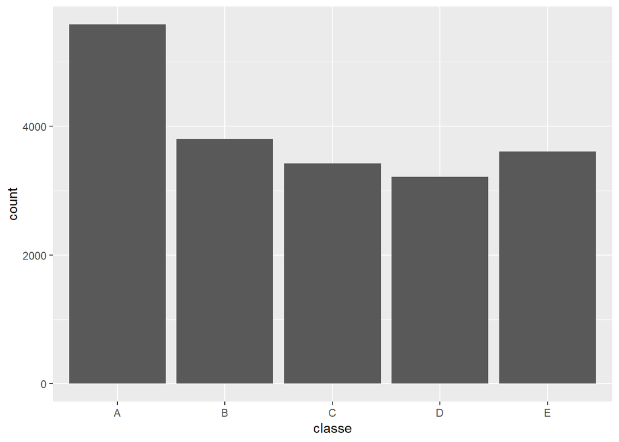

```r
ggplot(trainset, aes(x = classe)) + geom_histogram(stat = "count")
```

```r
colSums(is.na(trainset))
```

```
##                       V1                user_name     raw_timestamp_part_1
##                        0                        0                        0
##     raw_timestamp_part_2           cvtd_timestamp               new_window
##                        0                        0                        0
##               num_window                roll_belt               pitch_belt
##                        0                        0                        0
##                 yaw_belt         total_accel_belt       kurtosis_roll_belt
##                        0                        0                    19226
##      kurtosis_picth_belt        kurtosis_yaw_belt       skewness_roll_belt
##                    19248                    19622                    19225
##     skewness_roll_belt.1        skewness_yaw_belt            max_roll_belt
##                    19248                    19622                    19216
##           max_picth_belt             max_yaw_belt            min_roll_belt
##                    19216                    19226                    19216
##           min_pitch_belt             min_yaw_belt      amplitude_roll_belt
##                    19216                    19226                    19216
##     amplitude_pitch_belt       amplitude_yaw_belt     var_total_accel_belt
##                    19216                    19226                    19216
##            avg_roll_belt         stddev_roll_belt            var_roll_belt
##                    19216                    19216                    19216
##           avg_pitch_belt        stddev_pitch_belt           var_pitch_belt
##                    19216                    19216                    19216
##             avg_yaw_belt          stddev_yaw_belt             var_yaw_belt
##                    19216                    19216                    19216
##             gyros_belt_x             gyros_belt_y             gyros_belt_z
##                        0                        0                        0
##             accel_belt_x             accel_belt_y             accel_belt_z
##                        0                        0                        0
##            magnet_belt_x            magnet_belt_y            magnet_belt_z
##                        0                        0                        0
##                 roll_arm                pitch_arm                  yaw_arm
##                        0                        0                        0
##          total_accel_arm            var_accel_arm             avg_roll_arm
##                        0                    19216                    19216
##          stddev_roll_arm             var_roll_arm            avg_pitch_arm
##                    19216                    19216                    19216
##         stddev_pitch_arm            var_pitch_arm              avg_yaw_arm
##                    19216                    19216                    19216
##           stddev_yaw_arm              var_yaw_arm              gyros_arm_x
##                    19216                    19216                        0
```

[output cut: 53 more lines]

```
##                    19300                        0                    19216
##         avg_roll_forearm      stddev_roll_forearm         var_roll_forearm
##                    19216                    19216                    19216
##        avg_pitch_forearm     stddev_pitch_forearm        var_pitch_forearm
##                    19216                    19216                    19216
##          avg_yaw_forearm       stddev_yaw_forearm          var_yaw_forearm
##                    19216                    19216                    19216
##          gyros_forearm_x          gyros_forearm_y          gyros_forearm_z
##                        0                        0                        0
##          accel_forearm_x          accel_forearm_y          accel_forearm_z
##                        0                        0                        0
##         magnet_forearm_x         magnet_forearm_y         magnet_forearm_z
##                        0                        0                        0
##                   classe
##                        0
```

```r
colSums(is.na(testset))
```

```
##                       V1                user_name     raw_timestamp_part_1
##                        0                        0                        0
##     raw_timestamp_part_2           cvtd_timestamp               new_window
##                        0                        0                        0
##               num_window                roll_belt               pitch_belt
##                        0                        0                        0
##                 yaw_belt         total_accel_belt       kurtosis_roll_belt
##                        0                        0                       20
##      kurtosis_picth_belt        kurtosis_yaw_belt       skewness_roll_belt
##                       20                       20                       20
##     skewness_roll_belt.1        skewness_yaw_belt            max_roll_belt
##                       20                       20                       20
##           max_picth_belt             max_yaw_belt            min_roll_belt
##                       20                       20                       20
##           min_pitch_belt             min_yaw_belt      amplitude_roll_belt
##                       20                       20                       20
##     amplitude_pitch_belt       amplitude_yaw_belt     var_total_accel_belt
##                       20                       20                       20
##            avg_roll_belt         stddev_roll_belt            var_roll_belt
##                       20                       20                       20
##           avg_pitch_belt        stddev_pitch_belt           var_pitch_belt
##                       20                       20                       20
##             avg_yaw_belt          stddev_yaw_belt             var_yaw_belt
##                       20                       20                       20
##             gyros_belt_x             gyros_belt_y             gyros_belt_z
##                        0                        0                        0
##             accel_belt_x             accel_belt_y             accel_belt_z
##                        0                        0                        0
##            magnet_belt_x            magnet_belt_y            magnet_belt_z
##                        0                        0                        0
##                 roll_arm                pitch_arm                  yaw_arm
##                        0                        0                        0
##          total_accel_arm            var_accel_arm             avg_roll_arm
##                        0                       20                       20
##          stddev_roll_arm             var_roll_arm            avg_pitch_arm
##                       20                       20                       20
##         stddev_pitch_arm            var_pitch_arm              avg_yaw_arm
##                       20                       20                       20
##           stddev_yaw_arm              var_yaw_arm              gyros_arm_x
##                       20                       20                        0
```

[output cut: 53 more lines]

```
##                       20                        0                       20
##         avg_roll_forearm      stddev_roll_forearm         var_roll_forearm
##                       20                       20                       20
##        avg_pitch_forearm     stddev_pitch_forearm        var_pitch_forearm
##                       20                       20                       20
##          avg_yaw_forearm       stddev_yaw_forearm          var_yaw_forearm
##                       20                       20                       20
##          gyros_forearm_x          gyros_forearm_y          gyros_forearm_z
##                        0                        0                        0
##          accel_forearm_x          accel_forearm_y          accel_forearm_z
##                        0                        0                        0
##         magnet_forearm_x         magnet_forearm_y         magnet_forearm_z
##                        0                        0                        0
##               problem_id                   classe
##                        0                       20
```

A special function was created in order to detect missing data, which was afterwards used in order to create datasets with less missings. As a criterion, only variables with less than 90% of missing values were included into further analyses.

```r
excl_vector <- numeric()
for(i in 1:ncol(trainset)){
  if(sum(is.na(trainset[, ..i])) >= 17660){
   excl_vector<- c(excl_vector, i) }
  }
trainset_lessna <- trainset %>% select(-excl_vector)
```

Then, the original training dataset was split into two fraction, one of which was used to estimate the parameters and another which was used to cross-validate the outcomes. First seven columns were also removed from the data due to the lack of theoretical relevance for the subject.

```r
set.seed(696)
splitindex <- createDataPartition(trainset$classe, p = 0.7, list = F)
train1 <- trainset_lessna[splitindex, -c(1,2,3,4,5,6,7)]
traintest <- trainset_lessna[-splitindex, -c(1,2,3,4,5,6,7)]
```

## Data analysis

After the preparations were finished, random forest model was applied on the data.

```r
rfModel <- randomForest(classe~., data = train1)
rfModel
```

```
##
## Call:
##  randomForest(formula = classe ~ ., data = train1)
##                Type of random forest: classification
##                      Number of trees: 500
## No. of variables tried at each split: 7
##
##         OOB estimate of  error rate: 0.58%
## Confusion matrix:
##      A    B    C    D    E  class.error
## A 3903    2    1    0    0 0.0007680492
## B   14 2638    6    0    0 0.0075244545
## C    0   10 2383    3    0 0.0054257095
## D    0    0   32 2218    2 0.0150976909
## E    0    0    3    6 2516 0.0035643564
```

After forming the prediction model, it was cross-validated in order to assess its effectiveness in another context.

```r
rfpred <- predict(rfModel, traintest)
confusionMatrix(rfpred, traintest$classe)
```

```
## Confusion Matrix and Statistics
##
##           Reference
## Prediction    A    B    C    D    E
##          A 1673    4    0    0    0
##          B    1 1132   11    0    0
##          C    0    3 1015   13    1
##          D    0    0    0  951    0
##          E    0    0    0    0 1081
##
## Overall Statistics
##
##                Accuracy : 0.9944
##                  95% CI : (0.9921, 0.9961)
##     No Information Rate : 0.2845
##     P-Value [Acc > NIR] : < 2.2e-16
##
##                   Kappa : 0.9929
##  Mcnemar's Test P-Value : NA
##
## Statistics by Class:
##
##                      Class: A Class: B Class: C Class: D Class: E
## Sensitivity            0.9994   0.9939   0.9893   0.9865   0.9991
## Specificity            0.9991   0.9975   0.9965   1.0000   1.0000
## Pos Pred Value         0.9976   0.9895   0.9835   1.0000   1.0000
## Neg Pred Value         0.9998   0.9985   0.9977   0.9974   0.9998
## Prevalence             0.2845   0.1935   0.1743   0.1638   0.1839
## Detection Rate         0.2843   0.1924   0.1725   0.1616   0.1837
## Detection Prevalence   0.2850   0.1944   0.1754   0.1616   0.1837
## Balanced Accuracy      0.9992   0.9957   0.9929   0.9933   0.9995
```

The overall accuracy of the model was 99.44%, indicating and approximation of out-of sample error rate of 0.56%. In the end, the model was used to predict the test data.

```r
testpredict <- predict(rfModel, testset)
testpredict
```

```
##  1  2  3  4  5  6  7  8  9 10 11 12 13 14 15 16 17 18 19 20
##  B  A  B  A  A  E  D  B  A  A  B  C  B  A  E  E  A  B  B  B
## Levels: A B C D E
```

Thank you for reviewing my analysis :)